# E4 Results and Figures

Marissa Lee

September 15, 2014

*This code needs the following raw data file:* e4_trimmedData.txt

*This code does the following things:*

1. Analyzes variation in biomass and soil measurements in unplanted and monoculture pots
2. Analyzes variation in biomass and soil measurements in mixed community pots
3. Analyzes the relationship between Microstegium density treatment on the measured Microstegium abundance at harvest

*This code produces the following items:*

1. Unplanted and monoculture pots
- summary table (aggregated by plant): mean, se, n = ‘summary_monos.txt’
- figure 2: resps v plant = ‘fig2_monos.png’
- lme4 model: resp<-plant+(1|bk) and test of fixed effects = ‘termeffs_monos.txt’
2. Mixed community pots
- summary tables (aggregated by (1) mvtrt, (2) comptrt, and (3) factorial trts): mean, se, n = ‘summary_mixedcomm.txt’
- plot parameters to determine if correlated: logtotal/mvtrt, logtotal/comptrt = ‘param_correl.png’
- figure 3: resps v mvtrt, resps v logtotal = ‘fig3_mixedcomm.png’
3. Relationship between Microstegium density treatment on the measured Microstegium abundance at harvest
- plot of mvabund v mvtrt, mvrelabund v mvtrt
- lme4 models: mvabund/relmvabund<-mvtrt+(1|bk) and test of fixed effects = ‘termeffs_abund_mixedcomm.txt’

*Load libraries*

```r
library(doBy)
library(lme4)
# library(coefplot2)# this no longer exists for R version 3.1.1
library(coefplot)# hopefully this has the same functionality...
require(data.table)
```

*Import data*

*Modify…* Create a total aboveground biomass column by adding Microstegium biomass, Panicum biomass, Sorghum biomass per observation (pot). Make sure that block is coded as a factor. Create ‘compabund’ (aka Neighbor abundance) column by adding Panicum biomass and Sorghum biomass per observation (pot).

*Subset…* Subset data based on whether it is a monoculture or mixture pot, also subset by the species identity (in the case of monocultures) or the neighbor treatment (in the case of the mixtures).

# 1. UNPLANTED AND MONOCULTURE POTS

*Consolidate relevant data*

*Summarize and plot total dry aboveground biomass, soil moisture, nitrate, and nitrification*  
Run the Loop

```
## refitting model(s) with ML (instead of REML)
```

```
## refitting model(s) with ML (instead of REML)
## refitting model(s) with ML (instead of REML)
## refitting model(s) with ML (instead of REML)
```

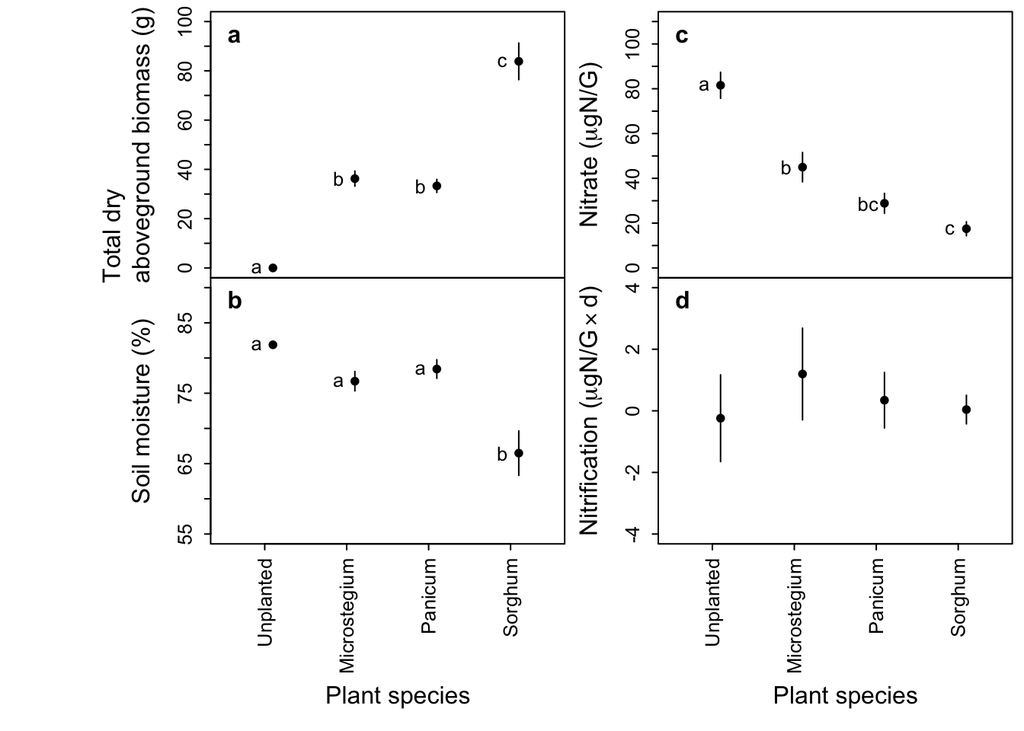

Check out the results

*LME model summary*… this isn’t working right now

```r
#export lme model summary, nested anova results
#THIS DOESN'T WORK BECAUSE OF LMER FXN UPDATE, SEE ABOVE
modelfits<-data.frame(modelfits)
#write.table(modelfits, file='modelfits_monos.txt', sep='\t', row.names=T, col.names=T)
colnames(termeffs)<-c('delAIC','Chisq','ChisqDF','pval')
rownames(termeffs)<-shortnames
#write.table(termeffs, file='termeffs_monos.txt', sep='\t', row.names=T, col.names=T)
```

*Do the same thing for ammonium, total inorganic N, ammonification, and mineralization*

```
## [1] "nhdi"     "totdi"    "ammonifd" "minzd"
```

```
## refitting model(s) with ML (instead of REML)
## refitting model(s) with ML (instead of REML)
## refitting model(s) with ML (instead of REML)
## refitting model(s) with ML (instead of REML)
```

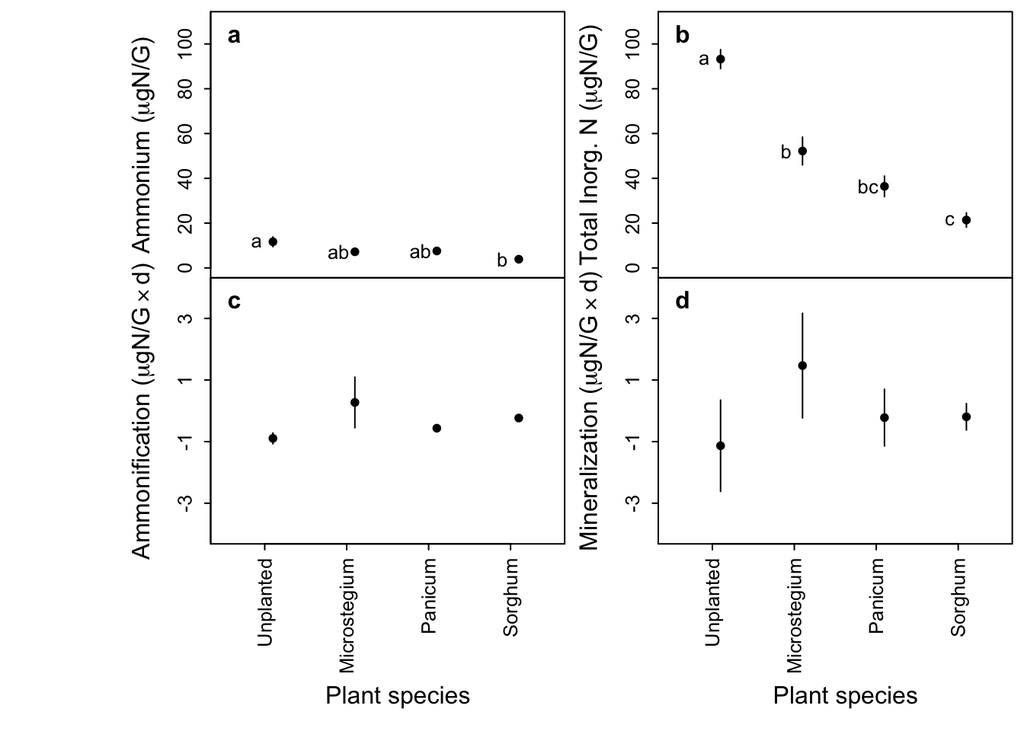

# 2. MIXED COMMUNITY POTS

*Consolidate relevant data*

*Summarize data for total dry aboveground biomass, soil moisture, nitrate, and nitrification*

*Plot Logtotal vs mvtrt and Logtotal vs neigtrt to evaluate their relationships*

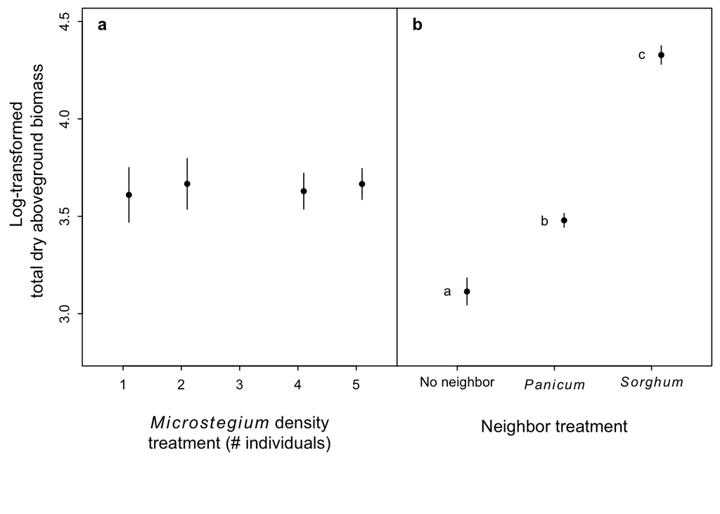

*Make more figures*

```
## refitting model(s) with ML (instead of REML)
## refitting model(s) with ML (instead of REML)
## refitting model(s) with ML (instead of REML)
## refitting model(s) with ML (instead of REML)
## refitting model(s) with ML (instead of REML)
```

```
## refitting model(s) with ML (instead of REML)
```

```
## refitting model(s) with ML (instead of REML)
```

[output not shown]

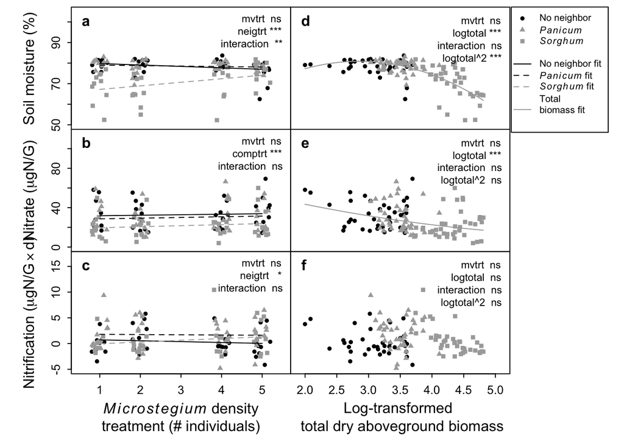

```
## refitting model(s) with ML (instead of REML)
## refitting model(s) with ML (instead of REML)
## refitting model(s) with ML (instead of REML)
```

# 3. MIXED COMMUNITY POTS - SUPPLEMENTAL

*Plot of mvabund v mvtrt, mvrelabund v mvtrt*, Not included in the ms

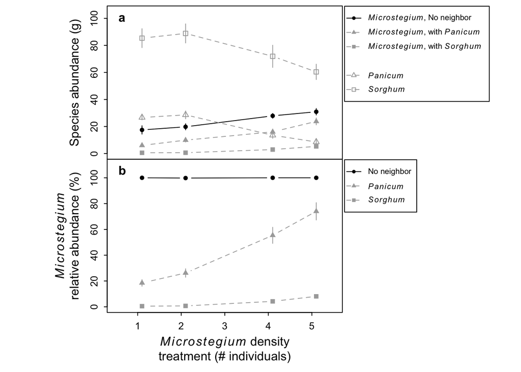

```
## refitting model(s) with ML (instead of REML)
## refitting model(s) with ML (instead of REML)
```

*Plot of ammonium, nitrate, total inorganic N*, Not included in the ms

[output not shown]

[output not shown]

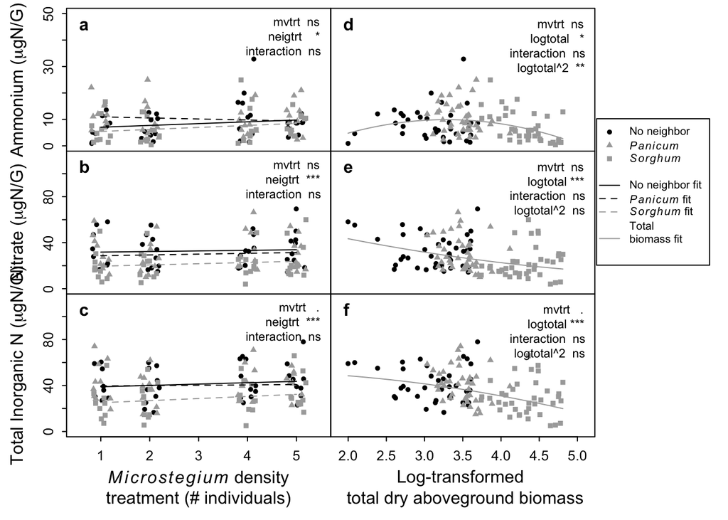

*Plot of ammonification, nitrification, mineralization*, Not included in the ms

[output not shown]

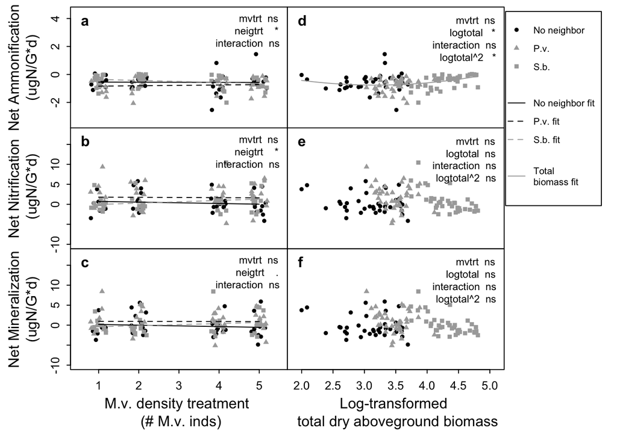

*Plot of ammonium, total inorganic N, ammonification, mineralization*, Not included in the ms

[output not shown]

[output not shown]

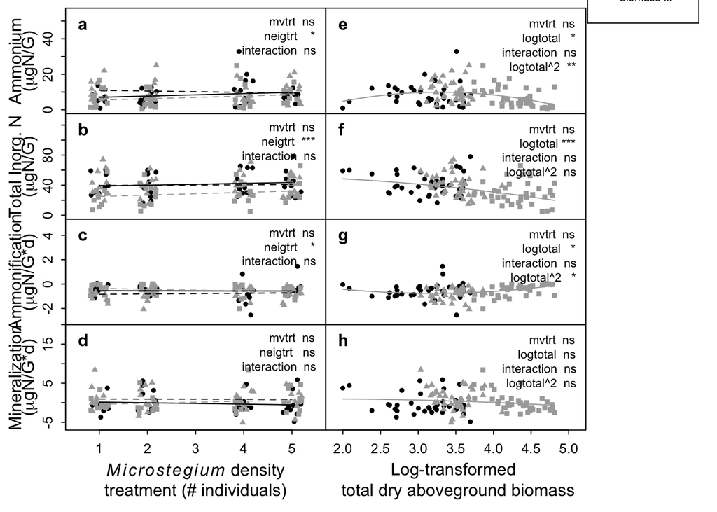